# Group Exercises: Classification

Ane Kleiven

2025-04-03

## Import R-packages from library

```r
library(BIAS.data)
library(MASS)
library(mixlm)
library(tidyverse)
library(ggfortify)
library(ggplot2)
```

## Import DATA

```r
poems <- BIAS.data::poems
poems.test <- BIAS.data::poems.test
```

## Exercise 1 - Analysis of ‘Deconstructed’ Poems by PCA

**Convert table into long format**

```r
poems.long <- poems %>%
pivot_longer(-Author, names_to = "letter", values_to = "freq") %>%
mutate(letter = as_factor(letter)) # convert 'letter' to factor to keep the order
poems.long
```

```
## # A tibble: 660 × 3
##    Author      letter   freq
##    <fct>       <fct>   <dbl>
##  1 Shakespeare a      0.0511
##  2 Shakespeare b      0.0221
##  3 Shakespeare c      0.0153
##  4 Shakespeare d      0.0341
##  5 Shakespeare e      0.118
##  6 Shakespeare f      0.0187
##  7 Shakespeare g      0.0204
##  8 Shakespeare h      0.0579
##  9 Shakespeare i      0.0494
## 10 Shakespeare j      0
## # ℹ 650 more rows
```

**Create a barplot of the frequency of letters in the poems**

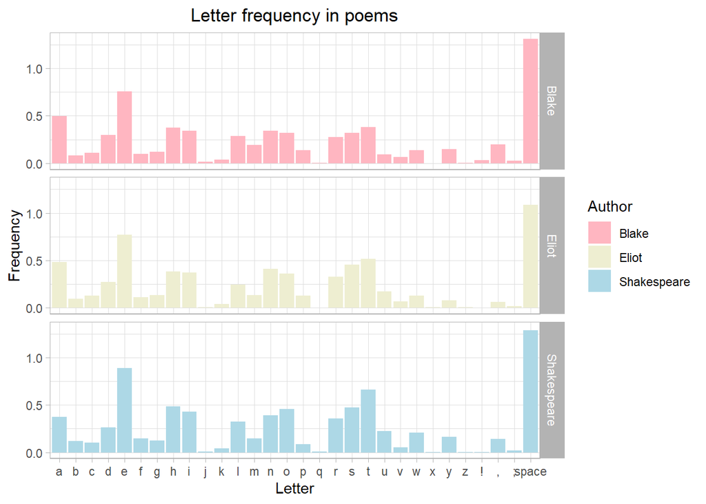

```r
ggplot() +
  geom_bar(data = poems.long, mapping = aes(x = letter, y = freq, fill = Author), stat = "identity") +   labs(x = "Letter", y = "Frequency", title = "Letter frequency in poems") +
  facet_grid(rows = vars(Author)) +
  theme_light() +
  scale_fill_manual(values = c("lightpink", "lightyellow2","lightblue")) +
  theme(plot.title = element_text(hjust = 0.5))
```

The distribution of letters looks quite equal for all the authors.

**Conduct a principal component analysis using the poem data. What portion of the total variance in the data is captured jointly by the two first components? How many principal components are needed to explain 80 % of the variability?**

```r
pca <- prcomp(poems[,-1], scale=TRUE)
summary(pca)
```

```
## Importance of components:
##                           PC1    PC2    PC3     PC4     PC5     PC6     PC7
## Standard deviation     2.4158 2.0752 1.8745 1.60611 1.52344 1.41857 1.27450
## Proportion of Variance 0.1945 0.1436 0.1171 0.08599 0.07736 0.06708 0.05415
## Cumulative Proportion  0.1945 0.3381 0.4552 0.54119 0.61856 0.68564 0.73978
##                           PC8     PC9    PC10    PC11    PC12    PC13    PC14
## Standard deviation     1.1988 1.10033 1.06592 0.99768 0.95035 0.73060 0.60864
## Proportion of Variance 0.0479 0.04036 0.03787 0.03318 0.03011 0.01779 0.01235
## Cumulative Proportion  0.7877 0.82804 0.86591 0.89909 0.92920 0.94699 0.95934
##                           PC15    PC16    PC17    PC18   PC19    PC20    PC21
## Standard deviation     0.58245 0.53702 0.47092 0.37338 0.3464 0.27495 0.18844
## Proportion of Variance 0.01131 0.00961 0.00739 0.00465 0.0040 0.00252 0.00118
## Cumulative Proportion  0.97064 0.98026 0.98765 0.99230 0.9963 0.99882 1.00000
##                             PC22
## Standard deviation     5.097e-16
## Proportion of Variance 0.000e+00
## Cumulative Proportion  1.000e+00
```

34 % of the variability is explained by the two first components. To explain 80 % of the variability, we need 9 principal components.

**Which variable (letter/character) has the largest influence (loading) on PC1 (have a look atpca$rotation)? Which variable is most influential on PC2?**

For PC1, “space” has the largest influence (about -0.33). It’s loading is negative, meaning that authors that use a lot of space in their poems end up with a low PC1 score. Other characters have almost equally large influence in PC1, namely “t” and “u”. However, they have a positive loading, meaning that authors that use a lot of t’s and u’s end up with a large PC1 score.

For PC2, the letters “l” and “n” have the largest influence, and has noteworthy larger loading compared to the other characters

```r
pca$rotation
```

```
##                PC1          PC2          PC3          PC4          PC5
## a     -0.253268506 -0.196412919 -0.187490760  0.085574641  0.210966487
## b      0.178035516  0.294185291  0.025440100  0.037566987  0.171383555
## c     -0.015968848 -0.063385440 -0.016459867 -0.438458042  0.238854649
## d     -0.144285169 -0.209539408 -0.074329101  0.203414219 -0.044424839
## e      0.139521413  0.293703198 -0.204335325 -0.196026984  0.158201099
## f      0.230436756  0.080147745 -0.064512737 -0.029245039 -0.130898859
## g     -0.046930053 -0.198653027  0.228070644 -0.028730835  0.279525883
## h      0.125146778  0.142602016  0.370849352  0.111414448 -0.069113492
## i      0.075679781 -0.128183308  0.197021310  0.321613021  0.288462304
## j     -0.165241033 -0.120811010  0.296270095 -0.189285157 -0.112041971
## k     -0.006309423  0.047089499  0.278116958 -0.161989119  0.023299950
## l     -0.020835425  0.434466407  0.024998972 -0.050012412  0.087270881
## m     -0.250742672  0.233939009 -0.185126330  0.069184371  0.027781820
## n      0.064806320 -0.400706345 -0.032143477 -0.095668773  0.049859566
## o      0.160193024 -0.063209422  0.396285855 -0.028188106 -0.161888947
## p     -0.146555104 -0.197756223  0.071190784 -0.033073549  0.160352954
## q      0.082421362 -0.038835500 -0.308641557  0.211125756 -0.001543814
## r      0.165256732 -0.299273777 -0.150482882 -0.171992789 -0.066775534
## s      0.254066101 -0.067931463  0.032141118 -0.042475965 -0.050152382
## t      0.315930395  0.140804647 -0.024764784  0.089585661  0.119675525
## u      0.298844028 -0.125626253 -0.005604713  0.024367565 -0.231205939
## v     -0.070146411  0.019017787 -0.192580037 -0.347010858 -0.098064977
## w      0.080794790  0.038977466 -0.062434196  0.379708345 -0.286884798
## x      0.188313509 -0.028217576 -0.271342420 -0.036978204  0.055202828
## y     -0.141170810 -0.078457265 -0.124414298  0.079151498 -0.477568411
## z      0.170323532 -0.149073572 -0.224673396 -0.116917003 -0.043496484
## !     -0.254624407  0.118077385  0.005947294 -0.009533425 -0.122891348
## ,     -0.240556547  0.124890499  0.019504227 -0.306874927 -0.269241314
## ;     -0.180659814 -0.004866851 -0.130597206  0.166707375  0.300172544
## space -0.325537717  0.046404629  0.057778252  0.169584606 -0.074418013
##                 PC6          PC7          PC8         PC9        PC10
## a      0.2011192958 -0.057014217 -0.015870692  0.08552931  0.25121811
## b      0.2761929651 -0.034387351 -0.299049863  0.05205718 -0.07804150
## c     -0.0587652410  0.029826721 -0.090731132 -0.37056987  0.15252754
## d      0.3251186990 -0.325985259 -0.210151296 -0.05414737  0.18481616
## e      0.1008422785  0.084807365  0.045132080  0.21300439 -0.27221593
## f     -0.0049480380 -0.346125353  0.367955159 -0.08717148 -0.10156473
## g      0.1559855945  0.033410051 -0.186298609  0.25333436 -0.21958891
## h      0.0248448559 -0.183031685 -0.128157550  0.16691758  0.09250465
```

[output cut: 100 more lines]

```
## p      0.15327101  0.106147180
## q      0.09829930  0.032459522
## r     -0.11539216  0.083565508
## s     -0.16182694 -0.143793105
## t     -0.23430138  0.242244791
## u     -0.04517761 -0.113933103
## v      0.01506505 -0.090828140
## w      0.04037607 -0.180395478
## x     -0.29154406  0.035136771
## y      0.17688689 -0.067168558
## z      0.25132842  0.148073484
## !     -0.29753833  0.107359957
## ,     -0.08935168  0.148070478
## ;     -0.12237611 -0.011322201
## space  0.05006177 -0.226456574
```

**Create a biplot and comment. Do you think PC1 and PC2 are good variables for discriminating between the three authors?.**

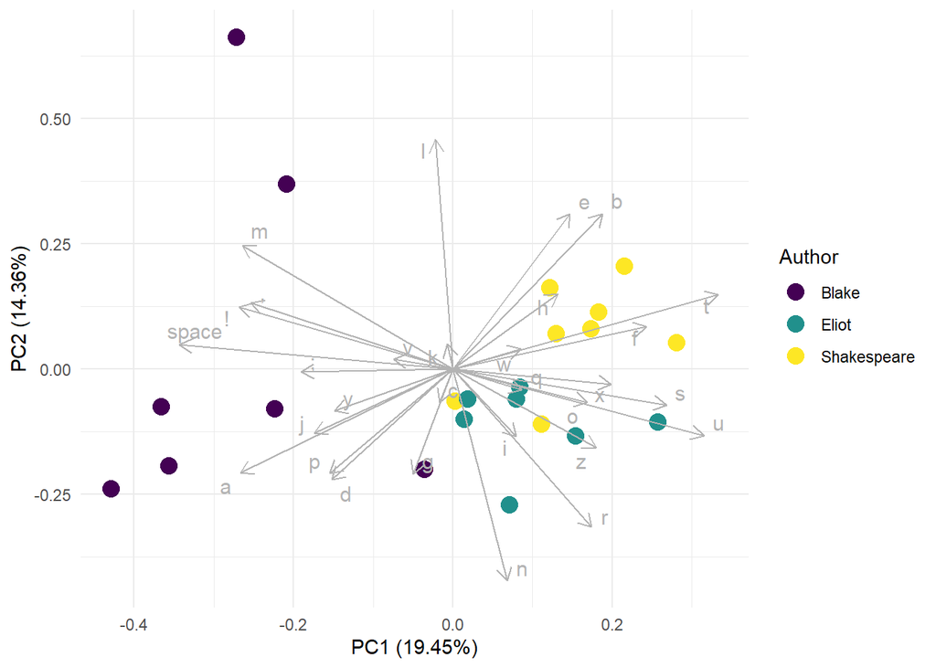

```r
autoplot(pca,
x = 1, # plot PC1 on the x-axis
y = 2, # plot PC2 on the y-axis (play around with this)
data = poems, # you have to refer to the original data set for colourscale = 0, # don't use the scaling implemented in autoplot()
size = 4, # size of points
loadings = TRUE,
loadings.label = TRUE,
loadings.label.size = 4,
loadings.label.repel = TRUE,
loadings.label.colour = "grey70",
loadings.colour = "grey70",
colour = "Author") +
scale_colour_viridis_d() +
theme_minimal()
```

Based on the biplot, Blake is well separated from the other two authors, while the other two authors are more similar and harder to discriminate.

The biplot combines the information from a scoreplot and the loadingplot. We see that poems written by Blake tend to be in the left half of the biplot. We infer from the biplot that poems of Blake contain more characters such as for instance space, exclamation mark (!), “a” and “m”.

We should be careful about the inferences above since only 34 % of the total variability in data is explained by PC1 and PC2, and because there are few data points (sample size is low). However, for these 22 poems, it seems that we can discriminate poems by Blake quite well from poems by Eliot and Shakespeare using PC1 and PC2. It seems harder to discriminate poems by Eliot from poems by Shakespeare using PC1 and PC2.

## Exercise 2 - Predicting authorship with LDA

**Compute the PC1- and PC2-scores of the poems in poems.test using the PCA from Exercise 1b).**

The purpose of the linear discriminant analysis is to find combination of the variables (PC1 and PC2) that give best possible separation between groups (Blake, Eliot, Shakespeare).

```r
scores.test <- predict(pca, newdata = poems.test[,-1])
scores.test <- cbind(Author = poems.test$Author, as_tibble(scores.test))
scores.test
```

```
##        Author        PC1        PC2        PC3        PC4         PC5
## 1 Shakespeare  3.9136323  1.3319443 -1.1169660 -1.7389198 -2.32377638
## 2 Shakespeare  1.2103595  0.8718919  1.4035316 -1.4831095 -1.37059168
## 3       Blake  0.3442297 -0.8672537  1.9535695 -1.6928408 -0.91702562
## 4       Blake -0.9636156 -1.9237165 -0.2112698 -0.2821465 -0.38333485
## 5       Eliot  3.0454523 -1.3419746 -1.6560653 -1.8836301  2.52978944
## 6       Eliot  1.4799615 -0.7610281 -0.5837241 -0.2428388 -0.01116067
##          PC6         PC7        PC8         PC9       PC10        PC11
## 1 -0.9397343 -0.00599067 -1.7846588  0.10208251  1.2352745  1.13913685
## 2 -1.1495221 -1.96209935  0.7949635  0.55409984  0.7704929 -0.23480134
## 3  1.3826043 -0.98275305 -0.1448373 -0.63678061 -0.4290403  1.30888775
## 4 -0.6413104 -0.81644363 -1.0130836  0.32640032 -0.5669068 -1.05881691
## 5  2.5002166  1.17765519 -0.4908587 -3.61870220  0.7830911 -1.19853250
## 6  0.9840082 -1.21568818  0.6548695 -0.09575747  0.9862488 -0.02946278
##         PC12       PC13       PC14       PC15        PC16         PC17
## 1  0.4091209  1.2356087 -0.2016212  1.5615912  2.39204801  0.006314123
## 2 -0.5084311  1.2270572  1.3450224  0.8736042  1.53476996 -0.496565396
## 3  0.2654943 -0.2313682 -0.3462967 -0.1791460 -0.23224049 -0.733424107
## 4 -1.7870994 -1.0446252 -1.0192751  0.3371612 -0.02075176  1.450085633
## 5  0.1534951  1.6249199  0.4313415 -1.7051011 -1.39612831 -1.071581614
## 6 -0.5017367 -0.9360946 -0.9680239  1.3120686  0.77474374  0.978942809
##          PC18       PC19        PC20       PC21        PC22
## 1 -1.47471763 -1.1302691  0.78916096 -1.9026131 -0.93676072
## 2 -0.20637255 -0.7571421  0.33141908 -0.9983007  1.13014308
## 3  0.36100292 -1.6395639 -1.88463268  0.2649253 -0.00584988
## 4  0.41879891  1.2680529  0.21975369 -0.3832447  0.09770024
## 5 -0.26276794 -0.2117775 -0.02190933  0.3644742  1.02446912
## 6  0.04921075  0.5126721 -0.39308447  0.8671660 -0.85642192
```

**Conduct a linear discriminant analysis (LDA) using PC1 and PC2 from exercise 1b) as predictors to classify the six ‘test’ poems to either Shakespeare, Blake or Eliot.**

```r
# First, we need to make a new data frame containing the information
# about the author and the first two principal components.
scores.poems <- cbind(Author = poems$Author, as_tibble(pca$x))

lda.poems <- lda(Author ~ PC1 + PC2, data = scores.poems)
lda.poems
```

```
## Call:
## lda(Author ~ PC1 + PC2, data = scores.poems)
##
## Prior probabilities of groups:
##       Blake       Eliot Shakespeare
##   0.3181818   0.3181818   0.3636364
##
## Group means:
##                   PC1        PC2
## Blake       -3.062886  0.3439229
## Eliot        1.095161 -1.0599280
## Shakespeare  1.721759  0.6265045
##
## Coefficients of linear discriminants:
##             LD1        LD2
## PC1  0.88562478 0.04059028
## PC2 -0.09990848 0.48757770
##
## Proportion of trace:
##    LD1    LD2
## 0.9665 0.0335
```

“Call” gives the linear discriminant analysis that was formulated. Here, we try to discriminate the Authors in the 22 poems based on PC1 and PC2, from the scores.poems data set. We have not included the 6 new poems in this analysis.

“Prior probabilities of groups” gives the prior probabilities of each group. Because we didn’t specify the prior probabilties in the lda() function, R uses the proportion of poems by each author as the prior probabilities.

“Group means” gives the group means in PC1 and PC2 for each author.

“Proportion of trace:” this is the percentage separation achieved by each linear discriminant function. About 97 % of the poems are separated by LD1, whereas the rest (3 %) are separated by LD2.

```r
# Then, predict the authorship of the 'test' poems
lda.pred <- predict(lda.poems, newdata = scores.test)
lda.pred
```

```
## $class
## [1] Shakespeare Shakespeare Eliot       Eliot       Shakespeare Eliot
## Levels: Blake Eliot Shakespeare
##
## $posterior
##          Blake     Eliot Shakespeare
## 1 3.258286e-08 0.1601106   0.8398894
## 2 5.220699e-04 0.3851660   0.6143120
## 3 5.163776e-03 0.6218313   0.3730049
## 4 2.174979e-01 0.6276543   0.1548478
## 5 2.907146e-07 0.4186158   0.5813839
## 6 9.936598e-05 0.5108222   0.4890784
##
## $x
##          LD1        LD2
## 1  3.3329373  0.8082817
## 2  0.9848150  0.4742439
## 3  0.3915043 -0.4088812
## 4 -0.6612062 -0.9770747
## 5  2.8312027 -0.5307012
## 6  1.3867238 -0.3109883
```

“Class” gives the predicted authorship for each of the 6 poems. We see that 3 poems are classified as Shakespeare poems, 3 poems are classified as Eliot poems, and 0 poems are classified as Blake poems.

“Posterior” is a matrix whose columns are the classes (authors), rows are the individual poems, and values are the posterior probability that the corresponding poem belongs to an author.

**The posterior probabilities are stored in lda.pred$posterior. Display the values using round(lda.pred$posterior, digits = 2). What is the predicted authorship of the different poems?**

```r
posterior_pred <- round(lda.pred$posterior, digits = 2)
posterior_pred
```

```
##   Blake Eliot Shakespeare
## 1  0.00  0.16        0.84
## 2  0.00  0.39        0.61
## 3  0.01  0.62        0.37
## 4  0.22  0.63        0.15
## 5  0.00  0.42        0.58
## 6  0.00  0.51        0.49
```

Predicted authorship:

- Poem 1: Shakespeare (84%)
- Poem 2: Shakespeare (61%)
- Poem 3: Eliot (62%)
- Poem 4: Eliot (63%)
- Poem 5: Shakespeare (58%)
- Poem 6: Eliot (51%)

**Write up a so-called confusion matrix for the test classification with true author as rows and classified authors as columns. Use the confusion() function from the package mixlm. What poems from which author are most difficult to predict? Compute the apparent error rate (APER) and the accuracy.**

```r
conf_mat <- confusion(lda.pred$class, scores.test$Author)
```

[output not shown]

Apparent error rate = 1 - accuracy = 0.5

Accuracy = 3/6 = 0.5

**How would you think one can improve the LDA? By adding more ‘test’ data (more observations in poems.test) or more ‘training’ data (data that the LDA is fit on, i.e. poems)**